# Modelos_Estatisticos-2024-08-31

Helena R. S. D’Espindula

2024-08-31

# Modelos lineares generalizados

Prof Cesar Augusto Taconeli

## Objetivo

Os modelos lineares generalizados configuram extensões do modelo de regressão linear, permitindo modelar, num contexto de regressão, variáveis respostas com distribuição pertencente à família exponencial de distribuições

## Sumário

1 Introdução 2 Família exponencial de distribuições 3 Modelo linear generalizado 4 Estimação 5 Inferência 6 Diagnóstico do ajuste 7 Regressão para dados binários 8 Modelos preditivos 9 Regressão para dados de contagens

## Introdução - Modelos Lineares Generalizados (GLM)

- Origem: Nelder e Wedderburn (1972): “Generalized Linear Models”, publicado no Journal of the Royal Statistical Society
- Extensão dos modelos lineares, incorporando, sob uma teoria unificada, diversos outros modelos propostos até então.
- Como casos particulares dos modelos lineares generalizados, temos os modelos de regressão linear, a regressão logística para resposta binária e o modelo log-linear para resposta de contagem.

## Família exponencial de distribuições

- Os modelos lineares generalizados permitem analisar, num contexto de regressão, variáveis respostas pertencentes à família exponencial de distribuições.
- Mais especificamente, assumimos que a função (densidade) de probabilidades de y possa ser expressa na seguinte forma:

$$f(y;\theta; \phi) = exp \space \{ \frac{y \theta - b \theta }{a(\phi)} +
c(y;\phi) \}$$

## Revisando

### Regressão Linear

$$y = \beta_0 + \beta_1 x_1 + \beta_2 x_2 + \cdot \cdot \cdot + \beta_k
x_k + \epsilon$$

$$\epsilon \sim N (0, \sigma^2)$$

$$y|x \sim N (\mu_x, \sigma^2)$$

$$E(y|x) = \mu_x = \beta_0 + \beta_1 x_1 + \beta_2 x_2 + ... + \beta_k x_k$$
### Modelo Linear Generalizado (GLM)

$$y|x \sim fe(\mu_x, \phi)$$
Sendo $fe$ familia? exponencial de probabilidades

$$g(\mu_x) = \beta_0 + \beta_1 x_1 + \beta_2 x_2 + \cdot \cdot \cdot +
\beta_k x_k$$
Sendo $g(u_x)$ a função de ligação

## Família exponencial de distribuições

Dentre as principais distribuições pertencentes à família exponencial, temos:

- Binomial (Bernoulli);
- Poisson;
- Normal;
- Gamma (exponencial);
- Normal inversa;
- Binomial negativa*.

$$x \sim N(\mu,\sigma^2) \{ E(x) = \mu; \space Var(x) = \sigma^2$$
$$y \sim Poisson(\mu) \{ E(x) = \mu; \space Var(x) = \mu$$

$$z \sim Bernoilli (\pi) \{ E(x) = \pi; \space Var(x) = \pi (1 - \pi)$$

## Distribuição binomial

A distribuição binomial é uma alternativa na modelagem de dados binários (dicotômicos). Como exemplos:

- E-mails classificados por um algoritmo como spam ou não spam;
- Clientes de um banco classificados como pagadores ou não pagadores;
- Pacientes submetidos a certo tipo de cirurgia que apresentam ou não determinada sequela;
- Resultados dos jogos da NBA (liga norte-americana de basquete) quanto à vitória ou derrota do time mandante.

[…]

## Definição de um modelo linear generalizado

- Um modelo linear generalizado é definido pela especificação de três componentes: o componente aleatório, o componente sistemático e uma função de ligação.
- Componente aleatório: Uma variável aleatória (resposta) com distribuição pertencente à família exponencial.
- Como vimos anteriormente, são membros dessa família as distribuições binomial, Poisson, normal, gama, normal inversa. . .
- Um modelo linear generalizado é definido da seguinte forma:
  $$y |x \sim f (\mu_x , \phi),$$

em que $f(\cdot)$ representa alguma particular distribuição pertencente à família exponencial, e
$$g(\mu_x ) = \eta x = \beta_0 + \beta_1 x_1 + ... + \beta_p x_p$$

em que $g(\cdot)$ é uma função real que desempenha a ligação dos componentes aleatório e sistemático do modelo.

## Componentes de um modelo linear generalizado

- Componente sistemático: preditor linear do modelo, em que são inseridas as covariáveis $(x_1, x_2, ..., x_p )$ e um conjunto de parâmetros associados em uma função linear.
  $$\eta x = \beta_0 + \beta_1 x_1 + ... + \beta_p x_p$$
- Função de ligação: Função real, monótona e diferenciável, denotada por $g(\cdot)$, que conecta os componentes aleatório e sistemático do modelo.

Seja $\mu$ = E (Y |x1, x2, …, xp ). Então:
$$g(\mu) = \eta = \beta_0 + \beta_1x_1 + \beta_2x_2 + ... + \beta_p x_p .$$
O modelo pode ser escrito de maneira equivalente por:
$$\mu = g-1(\eta) = g-1(\beta_0 + \beta_1x_i + \beta_2x_i + ... + \beta_p
x_i$$

## Especificação do componente aleatório

- Requer a definição de uma distribuição de probabilidades para a variável resposta.
- A variável resposta é discreta ou contínua? Sua distribuição é simétrica? Qual o conjunto de valores com probabilidade não nula?
- Deve-se propor uma distribuição que tenha propriedades compatíveis aos dados.
- Não se tendo convicção sobre uma particular escolha, pode-se testar diferentes alternativas ou usar alguma abordagem que não exija essa especificação.
- Quais variáveis explicativas devem ser consideradas?
- Como essas variáveis serão incorporadas ao modelo? Avaliar a necessidade (conveniência) de escalonar, transformar, categorizar ou incluir potências de variáveis numéricas. . .
- Avaliar a necessidade de incluir efeitos de interação entre variáveis.

## Especificação da função de ligação

- A função de ligação tem o papel de linearizar a relação entre os componentes aleatório e sistemático do modelo
- Deve produzir valores válidos para $\mu$ (ou $\pi$, no caso da distribuição binomial) para qualquer valor de
  $$\eta x = \beta_0 + \beta_1 x_1 + ... + \beta_p x_p$$
  Proporcionar interpretações práticas para os parâmetros de regressão $\beta$’s.

## Exemplo Auditoria

```r
########################################################################
### Dados sobre auditoria na prestação de contas de 3000 indivíduos.

### As variáveis são as segintes:
### valor: é  o valor da nota (em milhares de dólares)

### resultado: e a resposta é o resultado da auditoria (1, se a nota tem indício de fraude
### e 0, não tinha indícios). O objetivo é modelar o resultado da auditoria em função
### do valor da nota.

auditoria <- read.csv2('auditoria.csv')
head(auditoria, 25)
```

```
##    resultado valor
## 1          0  8.52
## 2          1 18.01
## 3          1 17.58
## 4          0 13.94
## 5          0 17.00
## 6          0 13.00
## 7          0 12.81
## 8          0 10.45
## 9          0  7.49
## 10         0 12.22
## 11         0 18.16
## 12         1 19.75
## 13         0 10.69
## 14         1 26.04
## 15         0  8.49
## 16         1 17.98
## 17         1 12.66
## 18         1 18.41
## 19         1 16.74
## 20         1 19.83
## 21         0 15.34
## 22         1 20.24
## 23         1 16.16
## 24         0 13.85
## 25         0  9.63
```

```r
options(device = 'x11')
```

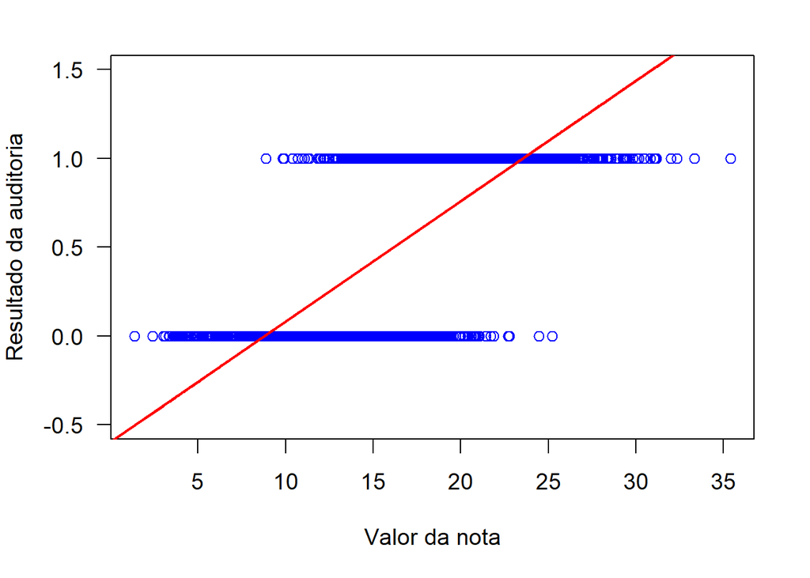

```r
par(las = 1, mar = c(5,4,2,2), cex = 1.2)
plot(resultado ~ valor, data = auditoria, ylim = c(-0.5, 1.5), col = 'blue',
     xlab = 'Valor da nota', ylab = 'Resultado da auditoria')
### Aparentemente, notas de maior valor estão mais propensas a indícios de fraude.

### Vamos ajustar um modelo de regressão linear.
ajuste <- lm(resultado ~ valor, data = auditoria)

abline(coef(ajuste), col = 'red', lwd = 2)
lines(sort(auditoria$valor), fitted(ajuste)[order(auditoria$valor)], col = 'red', lwd = 2)
```

```r
### O modelo ajustado claramente não é apropriado. Observe que para determinados
### valores da variável explicativa, temos valor ajustado inferior a zero
### ou superior a 1.
```

$$\pi = P(y=1) = P(fraude)$$

Regressão Linear:
$$\pi = \beta_0 +\beta_1 \times valor$$
Função de Ligação: Logito

$$ln(\frac{\pi}{1 - \pi}) = \beta_0 +\beta_1\times valor$$

$$\frac{\pi}{1 - \pi} = e^{\beta_0 +\beta_1\times valor}$$

$$\pi = \frac{e^{\beta_0 +\beta_1\times valor}}{e^{\beta_0 +\beta_1\times
valor} +1}$$

Tudo isso para ficar entre 0 e 1….

$$log(\frac{\hat{\pi}}{1-\hat{\pi}}) = -9,42 + 0,58 \times valor$$

$$\frac{\hat{\pi}}{1-\hat{\pi}} = e^{-9,42 + 0,58 \times valor}$$

$$\hat{\pi} = \frac{e^{-9,42 + 0,58 \times valor}}{e^{-9,42 + 0,58 \times
valor}+1}$$

```r
### Vamos contornar isso ajustando um modelo com resposta binomial, o que
### permitirá modelar a probabilidade de uma conta apresentar erros condicional
### ao valor da nota. Vamos avaliar diferentes funções de
### ligação que podem ser usadas na modelagem de dados binários.

par(las = 1, mar = c(5,4,2,2), cex = 1.2)
plot(resultado ~ valor, data = auditoria, pch = "|", ylim = c(0,1), col = 'lightblue',
     xlab = 'Valor da nota', ylab = 'Resultado da auditoria')


ajuste2 <- glm(resultado ~ valor, family = binomial(link = logit), data = auditoria)
### Ligação logito.
summary(ajuste2)
```

```
##
## Call:
## glm(formula = resultado ~ valor, family = binomial(link = logit),
##     data = auditoria)
##
## Coefficients:
##             Estimate Std. Error z value Pr(>|z|)
## (Intercept) -9.42164    0.34874  -27.02   <2e-16 ***
## valor        0.58420    0.02131   27.42   <2e-16 ***
## ---
## Signif. codes:  0 '***' 0.001 '**' 0.01 '*' 0.05 '.' 0.1 ' ' 1
##
## (Dispersion parameter for binomial family taken to be 1)
##
##     Null deviance: 4156.2  on 2999  degrees of freedom
## Residual deviance: 2163.5  on 2998  degrees of freedom
## AIC: 2167.5
##
## Number of Fisher Scoring iterations: 6
```

```r
lines(sort(auditoria$valor), predict(ajuste2, type = 'response')[order(auditoria$valor)],
      col = 'black', lwd = 2)
### Adicionando a regressão ajustada ao gráfico.


ajuste3 <- glm(resultado ~ valor, family = binomial(link = probit), data = auditoria)
### Ligação probito.
summary(ajuste3)
```

```
##
## Call:
## glm(formula = resultado ~ valor, family = binomial(link = probit),
##     data = auditoria)
##
## Coefficients:
##             Estimate Std. Error z value Pr(>|z|)
## (Intercept) -5.34183    0.17835  -29.95   <2e-16 ***
## valor        0.33095    0.01085   30.50   <2e-16 ***
## ---
## Signif. codes:  0 '***' 0.001 '**' 0.01 '*' 0.05 '.' 0.1 ' ' 1
##
## (Dispersion parameter for binomial family taken to be 1)
##
##     Null deviance: 4156.2  on 2999  degrees of freedom
## Residual deviance: 2164.7  on 2998  degrees of freedom
## AIC: 2168.7
##
## Number of Fisher Scoring iterations: 6
```

```r
lines(sort(auditoria$valor), predict(ajuste3, type = 'response')[order(auditoria$valor)],
      col = 'red', lwd = 2)


ajuste4 <- glm(resultado ~ valor, family = binomial(link = cloglog), data = auditoria)
### Ligação complemento log-log.
summary(ajuste4)
```

```
##
## Call:
## glm(formula = resultado ~ valor, family = binomial(link = cloglog),
##     data = auditoria)
##
## Coefficients:
##             Estimate Std. Error z value Pr(>|z|)
## (Intercept) -6.02785    0.20621  -29.23   <2e-16 ***
## valor        0.34154    0.01172   29.14   <2e-16 ***
## ---
## Signif. codes:  0 '***' 0.001 '**' 0.01 '*' 0.05 '.' 0.1 ' ' 1
##
## (Dispersion parameter for binomial family taken to be 1)
##
##     Null deviance: 4156.2  on 2999  degrees of freedom
## Residual deviance: 2239.1  on 2998  degrees of freedom
## AIC: 2243.1
##
## Number of Fisher Scoring iterations: 8
```

```r
lines(sort(auditoria$valor), predict(ajuste4, type = 'response')[order(auditoria$valor)],
      col = 'blue', lwd = 2)



ajuste5 <- glm(resultado ~ valor, family = binomial(link = cauchit), data = auditoria)
### Ligação Cauchy.
summary(ajuste5)
```

```
##
## Call:
## glm(formula = resultado ~ valor, family = binomial(link = cauchit),
##     data = auditoria)
##
## Coefficients:
##             Estimate Std. Error z value Pr(>|z|)
## (Intercept) -12.2010     0.7563  -16.13   <2e-16 ***
## valor         0.7576     0.0468   16.19   <2e-16 ***
## ---
## Signif. codes:  0 '***' 0.001 '**' 0.01 '*' 0.05 '.' 0.1 ' ' 1
##
## (Dispersion parameter for binomial family taken to be 1)
##
##     Null deviance: 4156.2  on 2999  degrees of freedom
## Residual deviance: 2233.1  on 2998  degrees of freedom
## AIC: 2237.1
##
## Number of Fisher Scoring iterations: 6
```

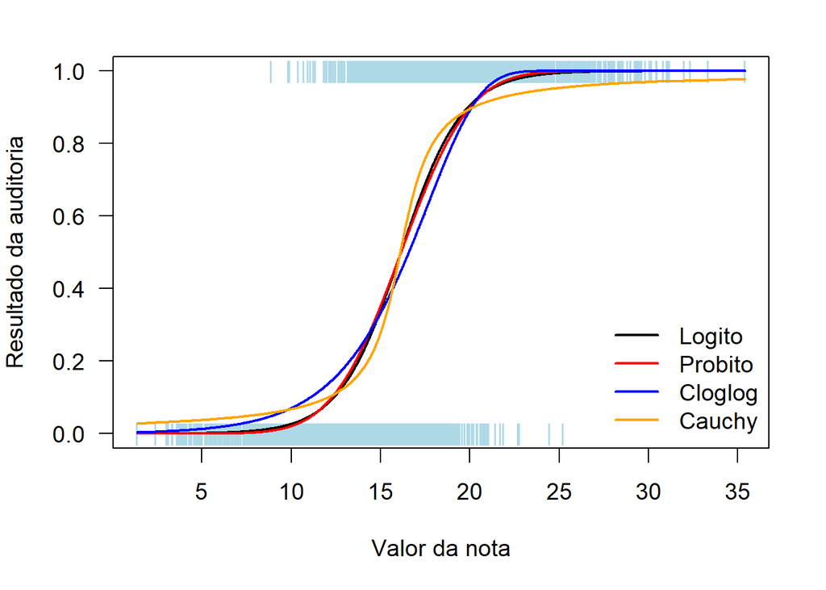

```r
lines(sort(auditoria$valor), predict(ajuste5, type = 'response')[order(auditoria$valor)],
      col = 'orange', lwd = 2)

legend(x = 'bottomright', lwd = 2, col = c('black', 'red', 'blue', 'orange'),
       legend = c('Logito', 'Probito', 'Cloglog', 'Cauchy'), bty = 'n')
```

```r
### Aparentemente, os modelos com ligação logito e probito proporcionam melhor
### ajuste que os demais. Além disso, os ajustes desses dois modelos são
### bastante semelhantes. Vamos comparar os modelos com base nos respectivos
### AICs.
```

```r
AIC(ajuste2, ajuste3, ajuste4, ajuste5)
```

```
##         df      AIC
## ajuste2  2 2167.462
## ajuste3  2 2168.702
## ajuste4  2 2243.110
## ajuste5  2 2237.070
```

```r
### O ajuste 2 (modelo com ligação logito) produziu menor AIC, sendo preferível.
```

## Exemplo Credito

```r
########################################################################
########################################################################
########################################################################
### Regressão para dados binários - modelo preditivo.
### Dados sobre concessão de crédito. O objetivo é modelar a variável
### resposta (default), que indica se o indíviduo atrasou (Yes) ou não (No)
### o pagamento da fatura do cartão de crédito. As variáveis explicativas
### são as seguintes:

### income: renda anual;
### balance: saldo devedor no cartão de crédito no último período;
### student: Yes, para estudante; No, caso contrário.

### Carregando os pacotes necessários para a análise.
require(ISLR)
require(statmod)
require(pROC)
require(car)
require(hnp)
```

```r
require(ggplot2)
### Carregamento e preparação dos dados.
data("Default")
#help("Default")
summary(Default)
```

```
##  default    student       balance           income
##  No :9667   No :7056   Min.   :   0.0   Min.   :  772
##  Yes: 333   Yes:2944   1st Qu.: 481.7   1st Qu.:21340
##                        Median : 823.6   Median :34553
##                        Mean   : 835.4   Mean   :33517
##                        3rd Qu.:1166.3   3rd Qu.:43808
##                        Max.   :2654.3   Max.   :73554
```

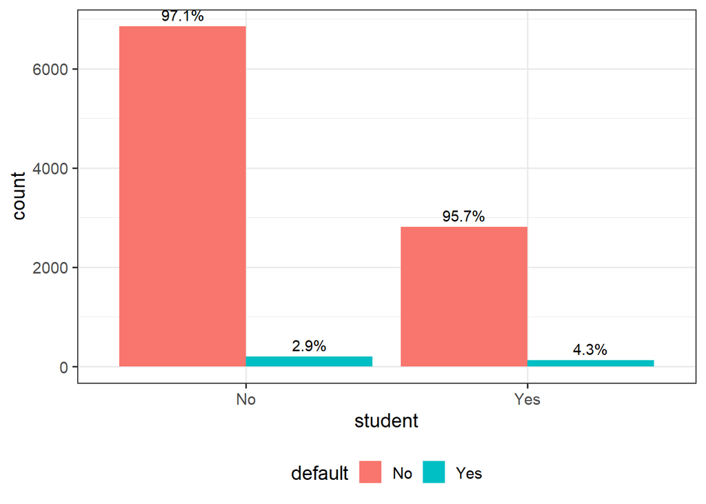

```r
Default$income <- Default$income/1000 ### Renda em x$1.000.

### Podemos observar que a frequência de devedores é bastante inferior à de
### não devedores.


########################################################################
########################################################################
########################################################################
### Análise exploratória.

ggplot(data = Default, aes(x = student, group = default, fill = default)) +
    geom_bar(stat = 'count', position = position_dodge())+
    theme_bw(base_size = 14)+
    theme(legend.position = 'bottom')+
    geom_text(aes( y=..count.., label=scales::percent(..count../tapply(..count.., ..x.. ,sum)[..x..], accuracy = 0.1L) ),
              stat="count", position=position_dodge(0.9), vjust=-0.5)
```

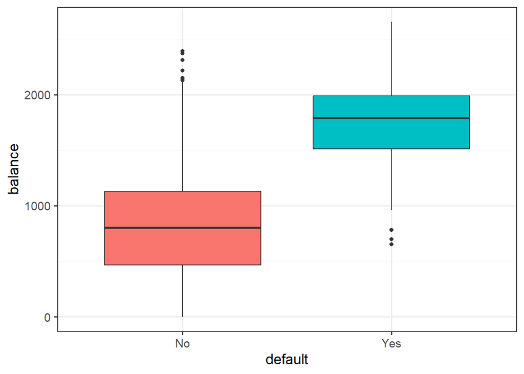

```r
ggplot(data = Default, aes(x = default, y = balance, fill = default)) +
    geom_boxplot()+
    theme_bw(base_size = 14)+
    theme(legend.position = 'none')
```

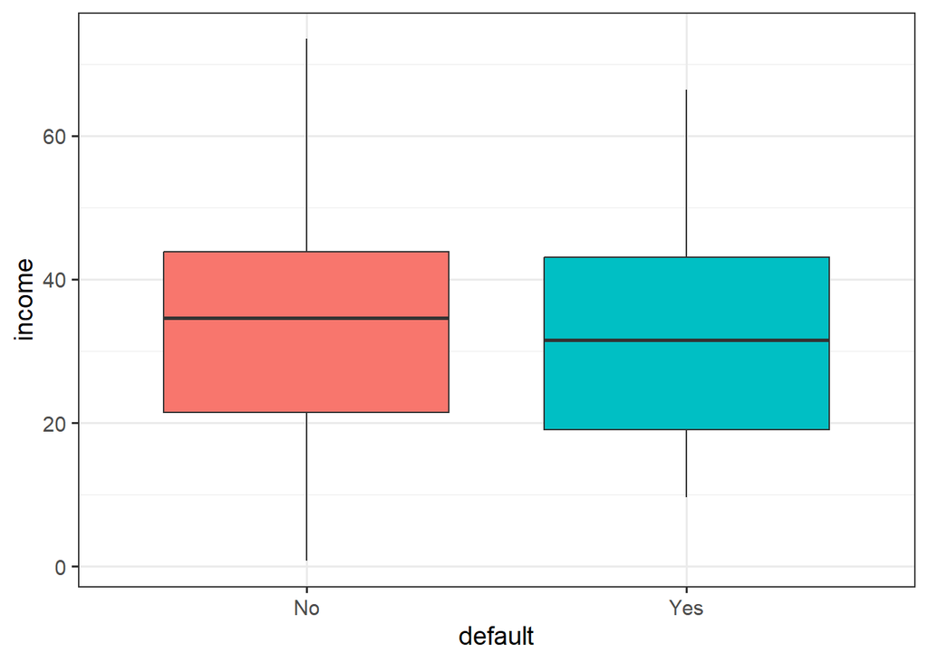

```r
ggplot(data = Default, aes(x = default, y = income, fill = default)) +
    geom_boxplot()+
    theme_bw(base_size = 14)+
    theme(legend.position = 'none')
```